# Clustering of Organoid Features

## 1.3 t-SNE

I look at the t-SNE for various perplexities. The coloring indicates the type of object; I differentiate between blurry objects, “organoids” with an area >= 1500 pixels, and “shrapnel” with an area of < 1500 pixels. The clustering shows a separation between blurry objects and organoids.

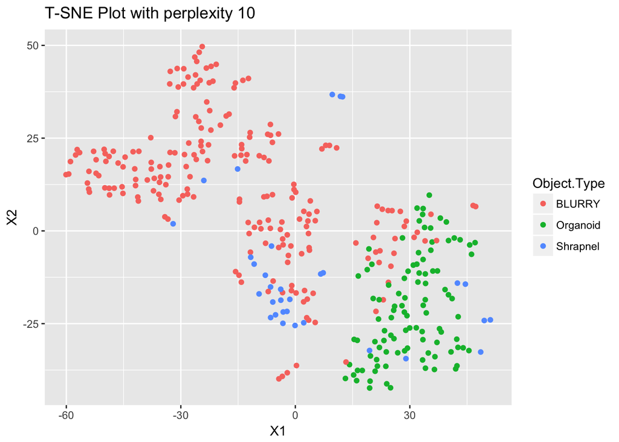

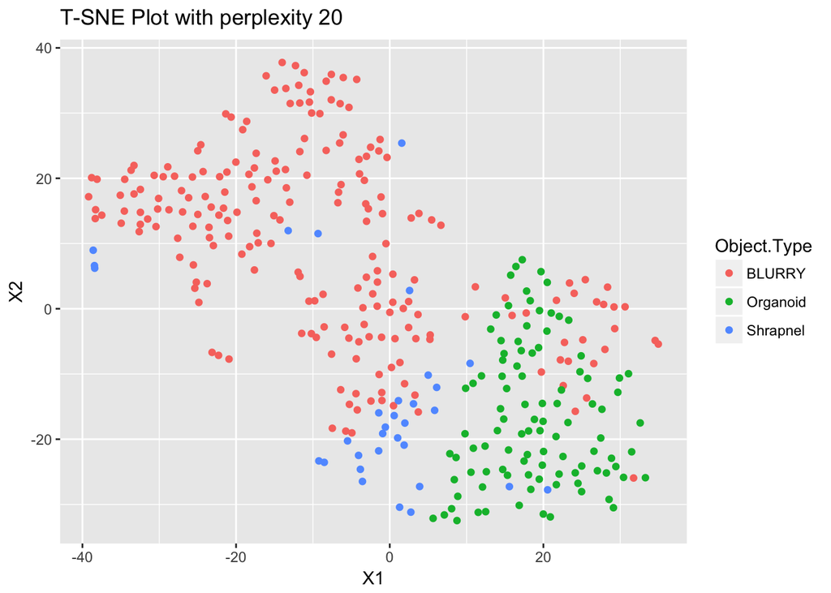

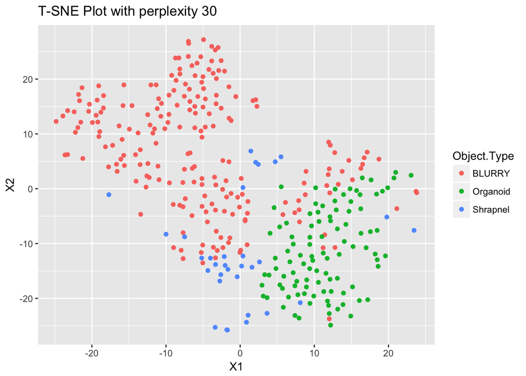

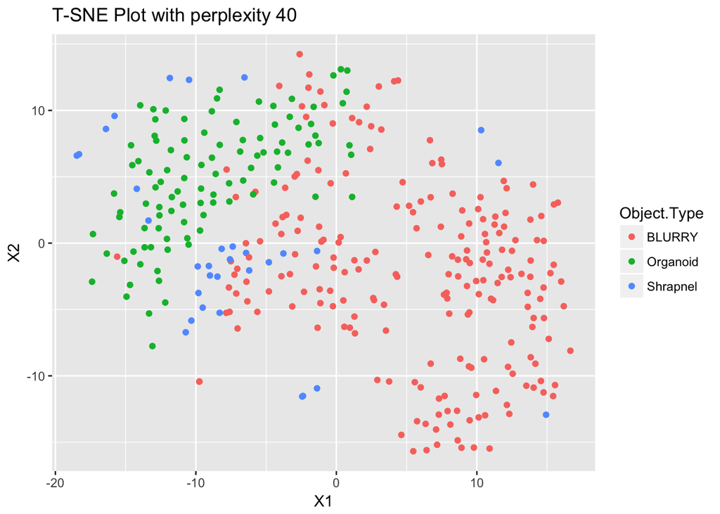

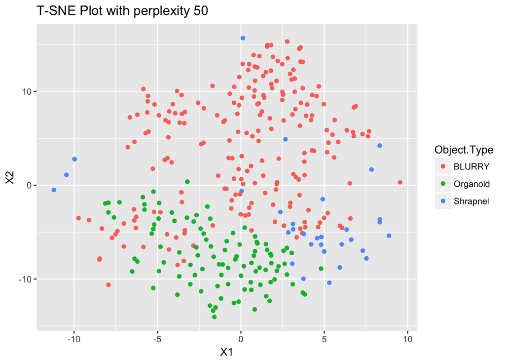

```r
perplexities = c(10, 20, 30, 40, 50)
tsne_data = lapply(perplexities, function(x) Rtsne(
  features, perplexity = x, initial_dims = 250,
  theta = 0, pca_scale = TRUE, pca_center = TRUE))
names(tsne_data) = perplexities
for(x in perplexities) {
  tsne_df = data.frame(tsne_data[[as.character(x)]]$Y)
  tsne_df$Object.Type = object_type
  plot(
    ggplot(data = tsne_df) + geom_point(aes(x = X1, y = X2, col = Object.Type)) +
      ggtitle(sprintf("T-SNE Plot with perplexity %s", x)))
}
```

## 1.4 Hierarchical Clustering

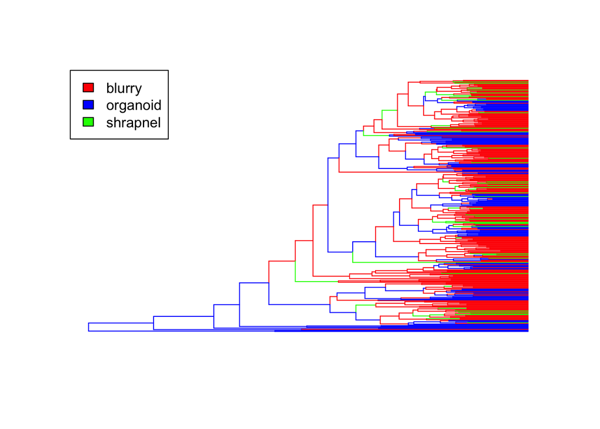

```r
d = dist(features_pca)
h = hclust(d)
colors = c("red", "blue", "green", "black")
plot.phylo(
  as.phylo(h), cex = 0.6, label.offset = 0.5, type = "phylogram",
  show.tip.label = FALSE, edge.color = colors[as.factor(object_type)],
  tip.color = colors[as.factor(object_type)])
legend(x="topleft",legend = levels(as.factor(tolower(object_type))), fill = colors,xpd = T, cex = 1)
```

## 1.5 K-Means Clustering

I take a look at the gap statistic (Tibshirani et al, 2000; Grün et al, 2015) to determine the optimal number of clusters.

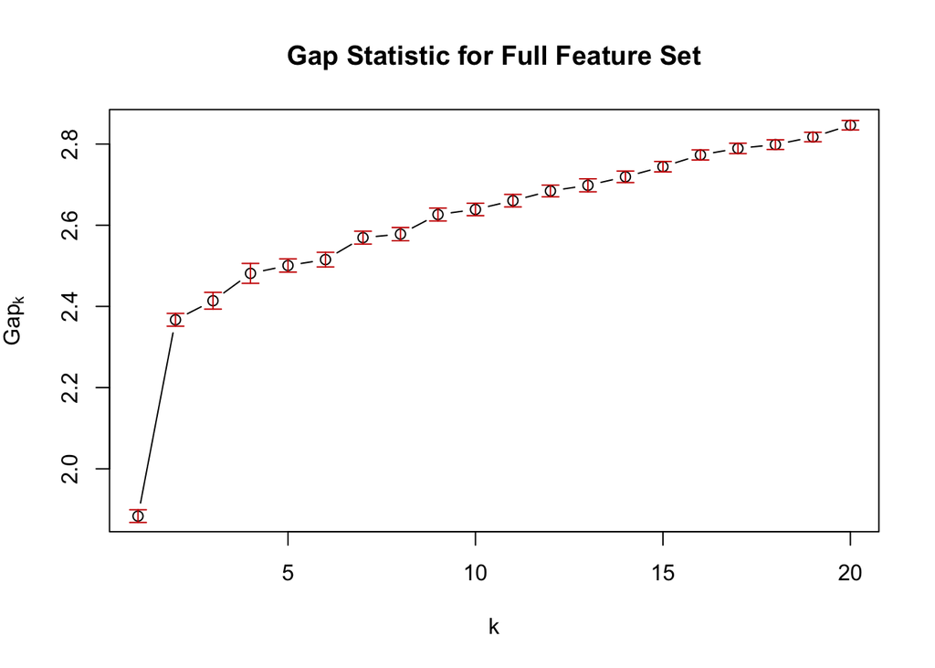

```r
pam1 = function(x, k) list(cluster = pam(x, k, cluster.only = TRUE))
gapstat = clusGap(x = features, FUNcluster = pam1, K.max = 20, B = 50, verbose = FALSE)
plot(gapstat, main = "Gap Statistic for Full Feature Set")
```

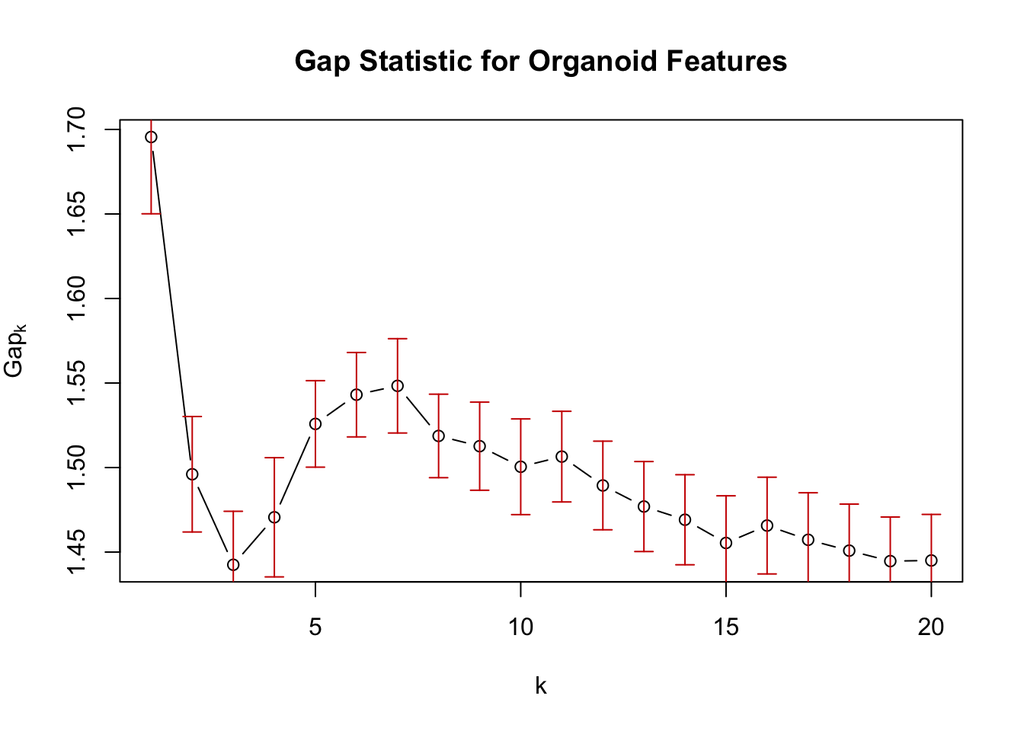

```r
gapstat = clusGap(
  x = features[object_type == "Organoid", ], FUNcluster = pam1,
  K.max = 20, B = 50, verbose = FALSE)
plot(gapstat, main = "Gap Statistic for Organoid Features")
```

## 1.6 Examples of clustered organoids

Next, I show some examples of the individual clusters to visually confirm the clustering. The clustering isn’t ideal, as three of the clusters have only one entry.

```r
object_id = seq_len(nrow(features))
object_id_organoids = object_id[object_type == "Organoid"]

# Perform clustering
clusters = pam1(x = features[object_type == "Organoid", ], k = 7)$cluster
print(table(clusters))
```

```
## clusters
##  1  2  3  4  5  6  7
##  5 46 44  1  1  2  1
```

```r
# Load and normalize projection
data_fn = projectionHdf5Filename(
  filedir = file.path(hdf5projection, plate), platename = plate,
  row = row, col = col, configdir = config_dir)
proj = h5read(data_fn, "images")
for(ch_i in 1:3) {
  for(field_i in 1:4) {
    q = quantile(proj[,,ch_i,field_i], 0.999)
    proj[,,ch_i,field_i][proj[,,ch_i,field_i] > q] = q
  }
  proj[,,ch_i,] = proj[,,ch_i,] - min(proj[,,ch_i,])
  proj[,,ch_i,] = proj[,,ch_i,] / max(proj[,,ch_i,])
}

# Load unaltered features for coordinates
orig_features_fn = file.path(
  feature_dir, plate, "wells",
  sprintf("%s_%s_%s_features.h5", plate, row, col))
features_original = h5read(orig_features_fn, sprintf("features_%s", feature_type))
colnames(features_original) = h5read(orig_features_fn, sprintf("feature_names_%s", feature_type))

# Extract sample organoids
num_samples = 5
valid_clusters = as.numeric(names(table(clusters)[table(clusters) >= num_samples]))
set.seed(20171110)
all_segments = list()
for(cl in valid_clusters) {
  cl_object_ids = sample(object_id_organoids[clusters == cl], num_samples, replace = FALSE)
  cl_coords = features_original[cl_object_ids, c("x.0.m.cx", "x.0.m.cy", "x.0.s.radius.max", "FIELD")]
  colnames(cl_coords) = c("x", "y", "radius", "field")
  segments = list()
  for(oid in seq_len(nrow(cl_coords))) {
    xx = round(cl_coords[oid, "x"])
    yy = round(cl_coords[oid, "y"])
    rad = ceiling(cl_coords[oid, "radius"]) + 10
    fld = cl_coords[oid, "field"]
    minx = max(xx - rad, 0)
    maxx = min(xx + rad, dim(proj)[1])
    miny = max(yy - rad, 0)
    maxy = min(yy + rad, dim(proj)[2])
    segments[[oid]] = proj[minx:maxx, miny:maxy, 1:3, fld]
  }
  all_segments[[as.character(cl)]] = segments
}

# Embed all segments into a single image
max_x = 0
max_y = 0
for(cl in all_segments) {
  for(seg in cl) {
    max_x = max(max_x, dim(seg)[1] + 5)
    max_y = max(max_y, dim(seg)[2] + 5)
  }
}

all_embed_segments = list()
ii = 1
for(cl in all_segments) {
  embed_segments = list()
  jj = 1
  for(seg in cl) {
    new_embed = array(0, dim = c(max_x, max_y, 3))
    ddim = round((dim(new_embed) - dim(seg))[1:2] / 2)
    new_embed[ddim[1]:(ddim[1] + dim(seg)[1] - 1), ddim[2]:(ddim[2] + dim(seg)[2] - 1), ] = seg
    new_embed[1:dim(new_embed)[1], 1, 1:3] = 1
    new_embed[1, 1:dim(new_embed)[2], 1:3] = 1
    embed_segments[[jj]] = new_embed
    jj = jj + 1
  }
  all_embed_segments[[ii]] = abind(embed_segments, along = 2)
  ii = ii + 1
}
all_embed_segments = Image(abind(all_embed_segments, along = 1), colormode = "color")
writeImage(all_embed_segments, "OrganoidClusters.png")
```